# Indeed.com NLP Text Classification Using R

Dillon

February 22, 2018

# 1 Introduction

The distinction between Data Scientist and Data Analyst is often hard to define. My goal is to use natural language processing (NLP) to classify Indeed.com job descriptions as Data Scientist or Data Analyst. I first gather the data by scraping the relevant listings using `RSelenium`. I then clean the text and convert the job listings to a corpus using the `tm` package. After, I create a document term matrix which counts the frequency of individual words for each job description. . Then I train naive bayes, KNN, random forest, LASSO, and ridge regression models with `caret` and evaluate their results against testing data.

You can download my code at github to follow along. You can use the `seattleData.RData` and `LAData.RData` files to replicate my results.

# 2 Setup

First, I load all relevant packages in environment.R:

```r
library(magrittr)
library(tm)
library(SnowballC)
library(wordcloud)
library(caret)
library(RSelenium)
library(dplyr)
library(stringr)
```

Setting up the RSelenium server:

```r
remDR <- rsDriver(port = 4444L, browser = c("chrome", "firefox", "phantomjs",
                                            "internet explorer"), version = "latest", chromever = "latest",
                  geckover = "latest", iedrver = NULL, phantomver = "2.1.1",
                  verbose = TRUE, check = TRUE)
cprof <- getChromeProfile("C:/Users/*YOUR USER NAME*/AppData/Local/Google/Chrome/User Data/", "Profile 1")
#"Profile 1" should be replaced by "Default" if you do not have multiple chrome user profiles
remDr <- remoteDriver(browserName = "chrome", extraCapabilities = cprof)
remDr$open()
```

Note: Indeed has sponsored job listings that repeat several times. To block these, use UBlock Origin and add `indeed.com##div.row.result[id^="pj_"]` to a custom user filter.

# 3 Scraping Indeed Job Data with RSelenium

Function to scrape Indeed job listings:

```r
findJobs <- function(url, jobLevel) {
    jobTitle <- c()
    jobDesc <- c()
    jobLev <- c()
    jobComp <- c()
    number <- 25
    remDr$navigate(url)
    stopLooking <- 0
    totalJobs <- length(jobDesc) + 1
    while (!stopLooking) {
        webElem <- remDr$findElements(using = "css selector", value = ".jobtitle .turnstileLink")
        jobNum <- length(unlist(webElem))
        job_counter <- 1
        start_job <- job_counter
        end_job <- min(start_job + 9, length(webElem))
        for (job in (start_job):(end_job)) {


            elem <- webElem[[job]]
            jobTitle[totalJobs] <- unlist(elem$getElementText())
            elem$clickElement()



            webElem2 <- tryCatch({
                suppressMessages({
                  webElem2 <- remDr$findElement(using = "css selector", value = "#vjs-content")
                  content <- webElem2$getElementText()
                  content
                })
            }, error = function(e) {
                FALSE
            })

            while (isTRUE(is.logical(webElem2))) {
                Sys.sleep(runif(1, 0.5, 2))
                webElem2 <- tryCatch({
                  suppressMessages({
                    webElem2 <- remDr$findElement(using = "css selector", value = "#vjs-content")
                    content <- webElem2$getElementText()
                    content
                  })
                }, error = function(e) {
                  FALSE
                })
            }
            jobDesc[totalJobs] <- unlist(webElem2)
            jobLev[totalJobs] <- jobLevel  #one denotes data scientist
            totalJobs <- totalJobs + 1
        }
        webElem3 <- remDr$findElements(using = "css selector", value = ".np")
        for (elements in 1:length(unlist(webElem3))) {
            stopLooking <- ifelse(webElem3[[elements]]$getElementText() == "Next Â»",
                0, 1)
            elementNum <- if (webElem3[[elements]]$getElementText() == "Next Â»") {
                number <- elements
            }
        }
        if (stopLooking == 0) {
            webElem3[[number]]$clickElement()
            Sys.sleep(runif(1, 0.5, 2))
        }


        Sys.sleep(runif(1, 0.5, 2))
    }
    output <- cbind(jobTitle, jobDesc, jobLev)
    output
}
```

Collecting data:

```r
#findJobs(url,level) - use 1 for level of data science jobs, 0 otherwise
dataScience <- findJobs("https://www.indeed.com/jobs?q=\"data+scientist\"&l=Seattle%2C+WA",1)
businessAnalyst <- findJobs("https://www.indeed.com/jobs?q=\"business analyst\"&l=Seattle,+WA",0)
businessIntAnalyst <- findJobs("https://www.indeed.com/jobs?q=\"business intelligence analyst\"&l=Seattle,+WA",0)
dataAnalyst <- findJobs("https://www.indeed.com/jobs?q=\"data analyst\"&l=Seattle,+WA",0)
```

# 4 Cleaning Data

To clean the data, I first remove any duplicate job listings in each category (data scientist, data analyst, business analyst, business intelligence analyst):

```r
#clean dataScience
uniqueIndex <- which(duplicated(dataScience[,"jobDesc"])==FALSE)
dataScienceClean <- dataScience[uniqueIndex,]
dataScienceClean <- as.data.frame(dataScienceClean,stringsAsFactors = FALSE)
dataScienceClean$jobLev <- factor(dataScienceClean$jobLev)
rm(uniqueIndex)

#clean busAnalyst
uniqueIndex <- which(duplicated(businessAnalyst[,"jobDesc"])==FALSE)
businessAnalystClean <- businessAnalyst[uniqueIndex,]
businessAnalystClean <- as.data.frame(businessAnalystClean,stringsAsFactors = FALSE)
businessAnalystClean$jobLev <- factor(businessAnalystClean$jobLev)
rm(uniqueIndex)

#clean busIntAnalyst
uniqueIndex <- which(duplicated(businessIntAnalyst[,"jobDesc"])==FALSE)
businessIntAnalystClean <- businessIntAnalyst[uniqueIndex,]
businessIntAnalystClean <- as.data.frame(businessIntAnalystClean,stringsAsFactors = FALSE)
businessIntAnalystClean$jobLev <- factor(businessIntAnalystClean$jobLev)
rm(uniqueIndex)

#clean dataAnalyst
uniqueIndex <- which(duplicated(dataAnalyst[,"jobDesc"])==FALSE)
dataAnalystClean <- dataAnalyst[uniqueIndex,]
dataAnalystClean <- as.data.frame(dataAnalystClean,stringsAsFactors = FALSE)
dataAnalystClean$jobLev <- factor(dataAnalystClean$jobLev)
rm(uniqueIndex)
```

Then, I combine `businessAnalystClean`, `businessIntAnalystClean`, and `dataAnalystClean` into a temporary data frame and remove remaining duplicates. After which I combine this temporary data frame with `dataScienceClean` and remove **all** job listings that appear in both the data scientist category and one of the other categories:

```r
#combine dataScienceClean with tempJobData and remove any duplicates
jobData <- rbind(dataScienceClean,tempJobData)
jobData <- as.data.frame(jobData,stringsAsFactors=FALSE)
jobData$jobLev <- factor(jobData$jobLev)
dupIndex <- which(duplicated(jobData$jobDesc) | duplicated(jobData$jobDesc, fromLast = TRUE) & jobData$jobLev==1)
jobData <- jobData[-dupIndex, ]
rm(dupIndex)
```

Since I am only interested in the words contained within the job listings, I need a function to delete numbers and punctuation:

```r
Clean_String <- function(string){
  # Lowercase
  temp <- tolower(string)
  #' Remove everything that is not a number or letter (may want to keep more
  #' stuff in your actual analyses).
  temp <- stringr::str_replace_all(temp,"[^a-zA-Z\\s]", " ")
  # Shrink down to just one white space
  temp <- stringr::str_replace_all(temp,"[\\s]+", " ")
  return(temp)
}

for(row in 1:nrow(jobData)){
  jobData$jobDesc[row] <- Clean_String(jobData$jobDesc[row])

}
```

## 4.1 Wordcloud of All Job Listings

I then randomly shuffle the data and use the `tm` package to create a corpus containing all of the job descriptions. I also create a wordcloud using the `wordcloud` package:

```r
#randomly shuffle data
set.seed(123)
jobData <- jobData[sample(nrow(jobData)),]
jobData <- jobData[sample(nrow(jobData)),]
```

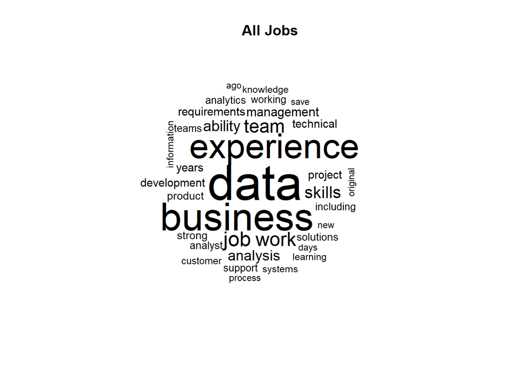

```r
job_corpus <- VCorpus(VectorSource(jobData$jobDesc))
job_corpus_clean <- tm_map(job_corpus, content_transformer(tolower))
job_corpus_clean <- tm_map(job_corpus_clean, removeNumbers)
job_corpus_clean <- tm_map(job_corpus_clean, removeWords, c(stopwords("english"),"will"))
job_corpus_clean <- tm_map(job_corpus_clean, removePunctuation)
par(mfrow=c(1,1))
wordcloud(job_corpus_clean, scale = c(4,.25),max.words = 35, random.order =FALSE)
title(main="All Jobs")
```

```r
job_corpus_clean <- tm_map(job_corpus_clean, stemDocument)
job_corpus_clean <- tm_map(job_corpus_clean, stripWhitespace)
```

## 4.2 Wordcloud Comparison

Here are wordclouds for Data Scientists versus Data Analysts, Business Analysts, and Business Intelligence Analysts:

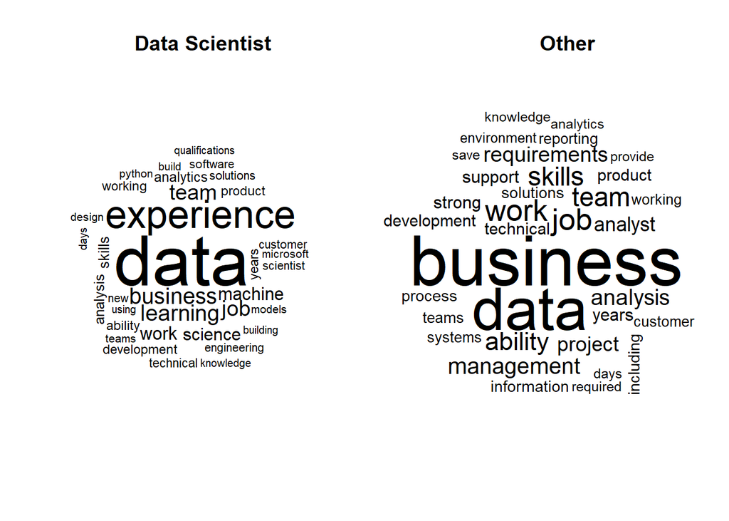

## 4.3 Creating the DTM and Training and Testing Sets

Next, I create a document term matrix (DTM). A DTM is a matrix that counts the frequencies with which words appear in a group of documents.

```r
job_dtm <- DocumentTermMatrix(job_corpus_clean)
```

Splitting the data into training and testing sets with a 70/30 split:

```r
smp_size <- floor(0.70 * nrow(job_dtm))
set.seed(123)
train_ind <- sample(seq_len(nrow(job_dtm)), size = smp_size)
job_dtm_train <- job_dtm[train_ind,]
job_dtm_test <- job_dtm[-train_ind,]
job_train_labels <- jobData[train_ind,"jobLev"]
job_test_labels <- jobData[-train_ind,"jobLev"]
```

# 5 Training the Models

## 5.1 Final Data Modifications

Before training the models, I limit the DTM to words that appear at least seven times (or are present in at least 1.3% of the documents). I then use the function `convert_counts` to convert the frequencies given in each DTM to a format that is usable by `caret`.

```r
  #find words that appear 7 times
  job_freq_words <- findFreqTerms(job_dtm_train, 7)


  job_dtm_freq_train <- job_dtm_train[ , job_freq_words]
  job_dtm_freq_test <- job_dtm_test[ , job_freq_words]

  #convert counts to "yes" or "no"
  convert_counts <- function(x) {
    x <- ifelse(x > 0, x, 0)
  }

  job_train <- apply(job_dtm_freq_train, MARGIN = 2, convert_counts)
  job_test <- apply(job_dtm_freq_test, MARGIN = 2, convert_counts)
```

## 5.2 Models

`Caret` makes training and evaluating multiple models very simple:

```r
#naive bayes
set.seed(123)
train_control <- trainControl(method="cv",number=10,verboseIter = TRUE)
job_nb <- train(job_train, job_train_labels,method="nb",trControl = train_control)

#knn
set.seed(123)
job_knn <- train(job_train, job_train_labels,method="knn",trControl = train_control)


#random forest
set.seed(123)
job_rf <- train(job_train, job_train_labels,method="rf",trControl = train_control)

#linear lasso
set.seed(123)
job_lasso <- train(job_train, job_train_labels,method="glmnet",trControl = train_control,
                    tuneGrid=expand.grid(
                      .alpha=1,
                      .lambda=seq(0, 100, by = 0.1)))

#linear ridge
set.seed(123)
job_ridge <- train(job_train, job_train_labels,method="glmnet",trControl = train_control,
                    tuneGrid=expand.grid(
                      .alpha=0,
                      .lambda=seq(0, 100, by = 0.1)))
```

# 6 Results

## 6.1 Naive Bayes

```r
#naive bayes results
nb_pred <- predict(job_nb,job_test)
cmnb <- confusionMatrix(nb_pred, job_test_labels, positive="1")
##confusion table
cmnb$table
##Accuracy Percentage
cmnb$overall[1]
```

```
##           Reference
## Prediction  1  0
##          1  0  0
##          0 68 99
```

```
##  Accuracy
## 0.5928144
```

## 6.2 KNN

```r
#knn results
knn_pred <- predict(job_knn,job_test)
cmknn <- confusionMatrix(knn_pred, job_test_labels, positive="1")
cmknn$table
cmknn$overall[1]
```

```
##           Reference
## Prediction  1  0
##          1 53  3
##          0 15 96
```

```
##  Accuracy
## 0.8922156
```

## 6.3 Random Forest

```r
#rf results
rf_pred <- predict(job_rf,job_test)
cmrf <- confusionMatrix(rf_pred, job_test_labels, positive="1")
cmrf$table
cmrf$overall[1]
```

```
##           Reference
## Prediction  1  0
##          1 64  1
##          0  4 98
```

```
##  Accuracy
## 0.9700599
```

## 6.4 LASSO

```r
#lasso results
lasso_pred <- predict(job_lasso,job_test)
cmlasso <- confusionMatrix(lasso_pred, job_test_labels, positive="1")
cmlasso$table
cmlasso$overall[1]
```

```
##           Reference
## Prediction  1  0
##          1 66  3
##          0  2 96
```

```
##  Accuracy
## 0.9700599
```

## 6.5 Ridge Regression

```r
#ridge results
ridge_pred <- predict(job_ridge,job_test)
cmridge <- confusionMatrix(ridge_pred, job_test_labels, positive="1")
cmridge$table
cmridge$overall[1]
```

```
##           Reference
## Prediction  1  0
##          1 40  1
##          0 28 98
```

```
##  Accuracy
## 0.8263473
```

## 6.6 Results Summary

```r
##All model accuracy
Accuracy <- data.frame("Model" = c("Naive Bayes","KNN","Random Forest","LASSO","Ridge"),"Accuracy" =as.numeric(c(cmnb$overall[1],cmknn$overall[1], cmrf$overall[1],             cmlasso$overall[1],cmridge$overall[1])),stringsAsFactors = FALSE)
Accuracy <- Accuracy %>% arrange(desc(Accuracy))
print(Accuracy)
```

```
##           Model  Accuracy
## 1 Random Forest 0.9700599
## 2         LASSO 0.9700599
## 3           KNN 0.8922156
## 4         Ridge 0.8263473
## 5   Naive Bayes 0.5928144
```

Random forest and LASSO are the most accurate models. The most important words in the random forest and LASSO models can be found by using the `varimp()` function:

```r
varImportanceRF <- varImp(job_rf)
print(varImportanceRF)
```

```
## rf variable importance
##
##   only 20 most important variables shown (out of 1744)
##
##           Overall
## scientist 100.000
## analyst    76.489
## machin     47.730
## algorithm  39.008
## learn      33.219
## python     29.982
## languag    23.521
## scienc     21.689
## phd        20.347
## statist    17.187
## engin      16.379
## report     14.680
## real       14.226
## spark      13.756
## busi       11.803
## model      11.344
## function    9.789
## mathemat    9.489
## build       9.404
## comput      8.054
```

```r
varImportanceLASSO <- varImp(job_lasso)
print(varImportanceLASSO)
```

```
## glmnet variable importance
##
##   only 20 most important variables shown (out of 1744)
##
##              Overall
## scientist     100.00
## statistician   63.15
## kindl          54.53
## diagnos        45.23
## analyst        41.08
## mechan         38.68
## mcio           37.45
## algorithm      34.30
## treatment      31.74
## agre           28.86
## though         28.05
## tensorflow     27.78
## push           25.87
## accuraci       21.66
## increment      21.14
## hutch          16.08
## languag        12.71
## machin         12.57
## sas            11.31
## hous           11.12
```

# 7 Model Performance on Los Angeles Jobs Data

97% accuracy is a decent result, but do the models only work on job listings in Seattle? I gathered a similar Indeed.com dataset from Los Angeles to test how my models perform on job listings in other cities:

```r
load("LAData.RData")

##DATA PROCESSING##

#clean LAdataScience
uniqueIndex <- which(duplicated(LAdataScience[,"jobDesc"])==FALSE)
LAdataScienceClean <- LAdataScience[uniqueIndex,]
LAdataScienceClean <- as.data.frame(LAdataScienceClean,stringsAsFactors = FALSE)
LAdataScienceClean$jobLev <- factor(LAdataScienceClean$jobLev)

rm(uniqueIndex)

#clean busAnalyst
uniqueIndex <- which(duplicated(LAbusinessAnalyst[,"jobDesc"])==FALSE)
LAbusinessAnalystClean <- LAbusinessAnalyst[uniqueIndex,]
LAbusinessAnalystClean <- as.data.frame(LAbusinessAnalystClean,stringsAsFactors = FALSE)
LAbusinessAnalystClean$jobLev <- factor(LAbusinessAnalystClean$jobLev)
rm(uniqueIndex)

#clean busIntAnalyst
uniqueIndex <- which(duplicated(LAbusinessIntAnalyst[,"jobDesc"])==FALSE)
LAbusinessIntAnalystClean <- LAbusinessIntAnalyst[uniqueIndex,]
LAbusinessIntAnalystClean <- as.data.frame(LAbusinessIntAnalystClean,stringsAsFactors = FALSE)
LAbusinessIntAnalystClean$jobLev <- factor(LAbusinessIntAnalystClean$jobLev)
rm(uniqueIndex)

#clean dataAnalyst
uniqueIndex <- which(duplicated(LAdataAnalyst[,"jobDesc"])==FALSE)
LAdataAnalystClean <- LAdataAnalyst[uniqueIndex,]
LAdataAnalystClean <- as.data.frame(LAdataAnalystClean,stringsAsFactors = FALSE)
LAdataAnalystClean$jobLev <- factor(LAdataAnalystClean$jobLev)
rm(uniqueIndex)

#combine busAnalystClean, businessIntAnalystClean, dataAnalystClean
#check for duplicates
tempJobData <- rbind(LAbusinessAnalystClean, LAbusinessIntAnalystClean, LAdataAnalystClean)
tempJobData <- as.data.frame(tempJobData,stringsAsFactors=FALSE)
tempJobData$jobLev <- factor(tempJobData$jobLev)
uniqueIndex <- which(duplicated(tempJobData$jobDesc)==FALSE)
tempJobData <- tempJobData[uniqueIndex,]
rm(uniqueIndex)

#combine dataScienceClean with tempJobData and remove any duplicates
LAjobData <- rbind(LAdataScienceClean,tempJobData)
LAjobData <- as.data.frame(LAjobData,stringsAsFactors=FALSE)
LAjobData$jobLev <- factor(LAjobData$jobLev)
dupIndex <- which(duplicated(LAjobData$jobDesc) | duplicated(LAjobData$jobDesc, fromLast = TRUE) & LAjobData$jobLev==1)
LAjobData <- LAjobData[-dupIndex, ]
rm(dupIndex)


for(row in 1:nrow(LAjobData)){
  LAjobData$jobDesc[row] <- Clean_String(LAjobData$jobDesc[row])

}

#randomly shuffle data
set.seed(123)
LAjobData <- LAjobData[sample(nrow(LAjobData)),]
LAjobData <- LAjobData[sample(nrow(LAjobData)),]


LAjob_corpus <- VCorpus(VectorSource(LAjobData$jobDesc))
LAjob_corpus_clean <- tm_map(LAjob_corpus, content_transformer(tolower))
LAjob_corpus_clean <- tm_map(LAjob_corpus_clean, removeNumbers)
LAjob_corpus_clean <- tm_map(LAjob_corpus_clean, removeWords, c(stopwords("english"),"will"))
LAjob_corpus_clean <- tm_map(LAjob_corpus_clean, removePunctuation)
LAjob_corpus_clean <- tm_map(LAjob_corpus_clean, stemDocument)
LAjob_corpus_clean <- tm_map(LAjob_corpus_clean, stripWhitespace)


LAjob_dtm <- DocumentTermMatrix(LAjob_corpus_clean,
                          control = list(dictionary=Terms(job_dtm_freq)))

LAjob_labels <- LAjobData[,"jobLev"]

LAjob_train_labels <- LAjobData[,"jobLev"]
LAjob_test_labels <- LAjobData[,"jobLev"]


LAjob_test <- apply(LAjob_dtm, MARGIN = 2, convert_counts)
##END DATA PROCESSING##
```

```r
##BEGIN PREDICTIONS USING MODEL TRAINED ON SEATTLE DATA##

#naive bayes results
LAnb_pred <- predict(job_nb,LAjob_test)
LAcmnb <- confusionMatrix(LAnb_pred, LAjob_test_labels, positive="1")
##confusion table
LAcmnb$table
##Accuracy Percentage
LAcmnb$overall[1]

#knn results
LAknn_pred <- predict(job_knn,LAjob_test)
LAcmknn <- confusionMatrix(LAknn_pred, LAjob_test_labels, positive="1")
LAcmknn$table
LAcmknn$overall[1]

#rf results
LArf_pred <- predict(job_rf,LAjob_test)
LAcmrf <- confusionMatrix(LArf_pred, LAjob_test_labels, positive="1")
LAcmrf$table
LAcmrf$overall[1]

#lasso results
LAlasso_pred <- predict(job_lasso,LAjob_test)
LAcmlasso <- confusionMatrix(LAlasso_pred, LAjob_test_labels, positive="1")
LAcmlasso$table
LAcmlasso$overall[1]

#ridge results
LAridge_pred <- predict(job_ridge,LAjob_test)
LAcmridge <- confusionMatrix(LAridge_pred, LAjob_test_labels, positive="1")
LAcmridge$table
LAcmridge$overall[1]

##END PREDICTIONS##
```

```r
##PRINT ACCURACY IN ORDER##

LAaccuracy <- data.frame("Model" = c("Naive Bayes","KNN","Random Forest","LASSO","Ridge"),"Accuracy" = as.numeric(c(LAcmnb$overall[1],LAcmknn$overall[1], LAcmrf$overall[1],
LAcmlasso$overall[1],LAcmridge$overall[1])),stringsAsFactors = FALSE)

LAaccuracy <- LAaccuracy %>% arrange(desc(Accuracy))
print(cbind(Accuracy,"LA Accuracy" = LAaccuracy$Accuracy))
```

```
##           Model  Accuracy LA Accuracy
## 1 Random Forest 0.9700599   0.9768977
## 2         LASSO 0.9700599   0.9686469
## 3           KNN 0.8922156   0.9191419
## 4         Ridge 0.8263473   0.9158416
## 5   Naive Bayes 0.5928144   0.8234323
```

The model actually performs even better on the Los Angeles dataset. This may be because Los Angeles has a lower percentage of data scientist listings in its dataset:

```r
#Percent of jobs classified as data scientist in Seattle data
length(which(jobData$jobLev==1))/nrow(jobData)
```

```
## [1] 0.3357401
```

```r
#Percent of jobs classified as data scientist in Los Angeles data
length(which(LAjobData$jobLev==1))/nrow(LAjobData)
```

```
## [1] 0.1765677
```

# 8 Conclusion

I began by gathering Indeed.com job listings for data scientists, data analysts, business analysts, and business intelligence analysts within the Seattle area using `RSelenium`. Then I clean the data and create a DTM which counts the frequency of individual words for each job description. After which I used `caret` to train naive bayes, KNN, random forest, LASSO, and ridge regression models with 10-fold cross-validation to classify job listings as data scientist or not. The most successful models were random forest and LASSO which both had 97% accuracy rates. More impressive, the models were very successful on a completely different dataset - job listings in Los Angeles. Random forest had a 97.70% accuracy rate and LASSO had a 96.86% accuracy rate.